# Coursera - Practical Machine Learning Project

Hasan

12 November, 2018

## Executive Summary

Using devices such as Jawbone Up, Nike FuelBand, and Fitbit it is now possible to collect a large amount of data about personal activity relatively inexpensively. These type of devices are part of the quantified self movement - a group of enthusiasts who take measurements about themselves regularly to improve their health, to find patterns in their behavior, or because they are tech geeks. One thing that people regularly do is quantify how much of a particular activity they do, but they rarely quantify how well they do it. In this project, your goal will be to use data from accelerometers on the belt, forearm, arm, and dumbell of 6 participants. They were asked to perform barbell lifts correctly and incorrectly in 5 different ways.  
*Summary from Coursera “Practical Machine Learning Course Project”*

## Read Data

```r
library(caret)
library(rattle)
```

```r
trainingUrl = "https://d396qusza40orc.cloudfront.net/predmachlearn/pml-training.csv"
testingUrl = "https://d396qusza40orc.cloudfront.net/predmachlearn/pml-testing.csv"

trainingfname = "pml-training.csv"
testingfname = "pml-testing.csv"

if(!file.exists(trainingfname)){
    download.file(trainingUrl, destfile = trainingfname)
}
if(!file.exists(testingfname)){
    download.file(testingUrl, destfile = testingfname)
}

training_or = read.csv2(file = trainingfname, header = T, sep = ",")
testing_or = read.csv2(file = testingfname, header = T, sep = ",")
```

## Preprocessing

```r
nearzero_training = nearZeroVar(training_or, saveMetrics = T)$nzv

#remove insignifacnt variables that have ~0 values
training = training_or[, nearzero_training == F]

#remove variables that have a mean of NAs above 70% of all values in that variable
training1 = training[,-which(colMeans(is.na(training)) > 0.7)]

#remove the first 6 columns as they hold data about the user which is not part of this study
training1 = training1[,-c(1:6)]

#transform all numeric values to numeric types for training and testing sets
for (i in 1:(ncol(training1) - 1)){
    training1[,i] = as.numeric(as.character(training1[,i]))
}

testing1 = testing_or[,names(training1)[1:52]]

for (i in 1:(ncol(testing1) - 1)){
    testing1[,i] = as.numeric(as.character(testing1[,i]))
}
```

## Create Validation Dataset

```r
set.seed(2334)
t = createDataPartition(training1$classe, p = 0.7, list = F)
#subset of the training data
training_1 = training1[t,]

#subset of the training data to be handled as validation dataset
training_2 = training1[-t,]

dim(training_1)
```

```
## [1] 13737    53
```

```r
dim(training_2)
```

```
## [1] 5885   53
```

After preprocessing, we went down to 53 variables from 160 originally.

## Train Model with RandomForest

Training model using random forest with cross validation of 4 folds.

```r
fit <- train(classe ~ ., data=training_1, method="rf",trControl = trainControl(method = "cv", number = 4, allowParallel = TRUE, verboseIter = F))

fit$finalModel
```

```
##
## Call:
##  randomForest(x = x, y = y, mtry = param$mtry)
##                Type of random forest: classification
##                      Number of trees: 500
## No. of variables tried at each split: 2
##
##         OOB estimate of  error rate: 0.74%
## Confusion matrix:
##      A    B    C    D    E  class.error
## A 3903    2    1    0    0 0.0007680492
## B   18 2631    9    0    0 0.0101580135
## C    0   18 2373    5    0 0.0095993322
## D    0    0   39 2211    2 0.0182060391
## E    0    0    2    5 2518 0.0027722772
```

## Cross Validation

```r
#using training_2 which is the validation data set
testModel = predict(fit, training_2)
accuracy = confusionMatrix(training_2$classe, testModel)
accuracy
```

```
## Confusion Matrix and Statistics
##
##           Reference
## Prediction    A    B    C    D    E
##          A 1674    0    0    0    0
##          B    7 1129    3    0    0
##          C    0   11 1012    3    0
##          D    0    0   19  945    0
##          E    0    0    0    1 1081
##
## Overall Statistics
##
##                Accuracy : 0.9925
##                  95% CI : (0.99, 0.9946)
##     No Information Rate : 0.2856
##     P-Value [Acc > NIR] : < 2.2e-16
##
##                   Kappa : 0.9905
##  Mcnemar's Test P-Value : NA
##
## Statistics by Class:
##
##                      Class: A Class: B Class: C Class: D Class: E
## Sensitivity            0.9958   0.9904   0.9787   0.9958   1.0000
## Specificity            1.0000   0.9979   0.9971   0.9962   0.9998
## Pos Pred Value         1.0000   0.9912   0.9864   0.9803   0.9991
## Neg Pred Value         0.9983   0.9977   0.9955   0.9992   1.0000
## Prevalence             0.2856   0.1937   0.1757   0.1613   0.1837
## Detection Rate         0.2845   0.1918   0.1720   0.1606   0.1837
## Detection Prevalence   0.2845   0.1935   0.1743   0.1638   0.1839
## Balanced Accuracy      0.9979   0.9941   0.9879   0.9960   0.9999
```

```r
error = 1 - accuracy$overall[['Accuracy']]
error
```

```
## [1] 0.007476636
```

```r
varImp(fit)
```

```
## rf variable importance
##
##   only 20 most important variables shown (out of 52)
##
##                      Overall
## roll_belt             100.00
## yaw_belt               81.16
## magnet_dumbbell_z      65.21
## pitch_forearm          65.01
## magnet_dumbbell_y      62.35
## pitch_belt             60.27
## magnet_dumbbell_x      51.86
## roll_forearm           48.14
## accel_belt_z           45.89
## magnet_belt_z          44.59
## accel_dumbbell_y       43.88
## roll_dumbbell          41.51
## magnet_belt_y          40.52
## accel_dumbbell_z       36.41
## roll_arm               35.61
## accel_forearm_x        32.10
## gyros_belt_z           30.06
## accel_dumbbell_x       29.81
## total_accel_dumbbell   29.03
## yaw_dumbbell           28.21
```

We can see the most important variables in impacting the accuracy of 99%

## Training with RPART

```r
fit2 <- train(classe ~ ., data=training_1, method="rpart",trControl = trainControl(method = "cv", number = 4, allowParallel = TRUE, verboseIter = F))

fit2$finalModel
```

```
## n= 13737
##
## node), split, n, loss, yval, (yprob)
##       * denotes terminal node
##
##  1) root 13737 9831 A (0.28 0.19 0.17 0.16 0.18)
##    2) roll_belt< 130.5 12563 8667 A (0.31 0.21 0.19 0.18 0.11)
##      4) pitch_forearm< -33.15 1109   14 A (0.99 0.013 0 0 0) *
##      5) pitch_forearm>=-33.15 11454 8653 A (0.24 0.23 0.21 0.2 0.12)
##       10) magnet_dumbbell_y< 439.5 9697 6960 A (0.28 0.18 0.24 0.19 0.11)
##         20) roll_forearm< 122.5 6042 3581 A (0.41 0.18 0.19 0.17 0.061) *
##         21) roll_forearm>=122.5 3655 2455 C (0.076 0.18 0.33 0.23 0.18) *
##       11) magnet_dumbbell_y>=439.5 1757  856 B (0.036 0.51 0.042 0.22 0.18) *
##    3) roll_belt>=130.5 1174   10 E (0.0085 0 0 0 0.99) *
```

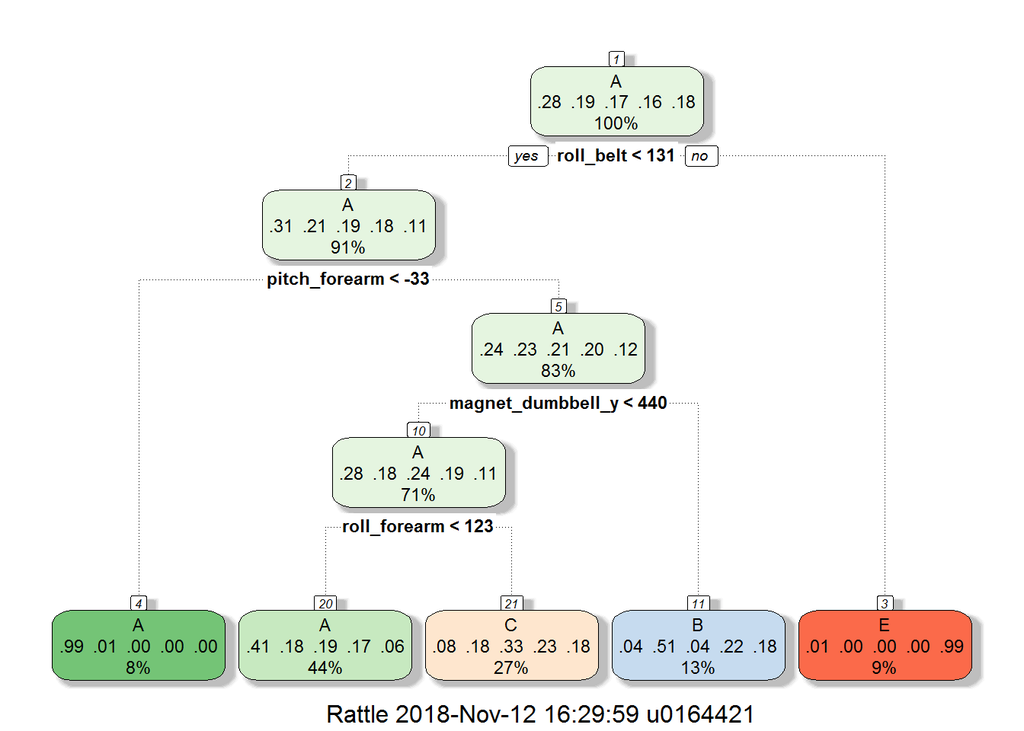

```r
fancyRpartPlot(fit2$finalModel)
```

The accuracy of the RPART model (49%) is very low compare to RandomForest.

```r
#using training_2 which is the validation data set
testModel2 = predict(fit2, training_2)
accuracy2 = confusionMatrix(training_2$classe, testModel2)
accuracy2
```

```
## Confusion Matrix and Statistics
##
##           Reference
## Prediction    A    B    C    D    E
##          A 1524   17  129    0    4
##          B  474  385  280    0    0
##          C  463   35  528    0    0
##          D  431  174  359    0    0
##          E  158  161  296    0  467
##
## Overall Statistics
##
##                Accuracy : 0.4935
##                  95% CI : (0.4806, 0.5063)
##     No Information Rate : 0.5183
##     P-Value [Acc > NIR] : 0.9999
##
##                   Kappa : 0.3381
##  Mcnemar's Test P-Value : NA
##
## Statistics by Class:
##
##                      Class: A Class: B Class: C Class: D Class: E
## Sensitivity            0.4997  0.49870  0.33166       NA  0.99151
## Specificity            0.9471  0.85253  0.88400   0.8362  0.88641
## Pos Pred Value         0.9104  0.33802  0.51462       NA  0.43161
## Neg Pred Value         0.6376  0.91846  0.78102       NA  0.99917
## Prevalence             0.5183  0.13118  0.27052   0.0000  0.08003
## Detection Rate         0.2590  0.06542  0.08972   0.0000  0.07935
## Detection Prevalence   0.2845  0.19354  0.17434   0.1638  0.18386
## Balanced Accuracy      0.7234  0.67562  0.60783       NA  0.93896
```

## Prediction using the RandomForest

Predicting on test data set

```r
predict(fit, testing1)
```

```
##  [1] B A B A A E D B A A B C B A E E A B B B
## Levels: A B C D E
```

## Conclusion

The randomforest model gives the highest accuracy from this study.